# HW2

## Homework 2

Import the libraries that is needed for the task.

```python
import os
import glob
import pandas as pd
import numpy as np
import random
import matplotlib.pyplot as plt
from mpl_toolkits.mplot3d import Axes3D
```

The dataset is provided in the following link: https://drive.google.com/drive/u/1/folders/13553neknux7U8why55KM1WrjgkA9IJKm

# Task A

Read the data

```python
os.chdir('C:/Users/Ozan Ozturk/Desktop/Files/HW2/data')
files=glob.glob('*')

list_of_dfs=[pd.read_csv(k,delim_whitespace=True,header=None) for k in files]

df1=list_of_dfs[0]
df2=list_of_dfs[1]
df3=list_of_dfs[2]
```

```python
df1
```

|  | 0 | 1 | 2 | 3 | 4 | 5 | 6 | 7 | 8 | 9 | ... | 306 | 307 | 308 | 309 | 310 | 311 | 312 | 313 | 314 | 315 |
| --- | --- | --- | --- | --- | --- | --- | --- | --- | --- | --- | --- | --- | --- | --- | --- | --- | --- | --- | --- | --- | --- |
| 0 | 6.0 | -0.304243 | -0.304243 | -0.304243 | -0.304243 | -0.304243 | -0.304243 | -0.304243 | -0.304243 | -0.304243 | ... | -0.796414 | -0.741728 | -0.694698 | -0.647669 | -0.647669 | -0.647669 | -0.647669 | -0.647669 | -0.647669 | -0.647669 |
| 1 | 5.0 | 1.627311 | 1.627311 | 1.627311 | 1.627311 | 1.627311 | 1.627311 | 1.627311 | 1.627311 | 1.627311 | ... | -0.237634 | -0.237634 | -0.237634 | -0.237634 | -0.237634 | -0.237634 | -0.237634 | -0.237634 | -0.237634 | -0.237634 |
| 2 | 5.0 | 0.661277 | 0.661277 | 0.661277 | 0.661277 | 0.661277 | 0.661277 | 0.661277 | 0.661277 | 0.661277 | ... | -0.282011 | -0.236929 | -0.191848 | -0.146766 | -0.101685 | -0.061203 | -0.056638 | -0.055462 | -0.055462 | -0.055462 |
| 3 | 3.0 | 0.005185 | 0.005185 | 0.005185 | 0.005185 | 0.005185 | 0.005185 | 0.005185 | 0.005185 | 0.005185 | ... | 1.207290 | 1.147822 | 1.094344 | 1.060362 | 1.053158 | 1.044467 | 1.018981 | 0.909949 | 0.791013 | 0.672077 |
| 4 | 4.0 | 1.286198 | 1.286198 | 1.286198 | 1.286198 | 1.286198 | 1.286198 | 1.286198 | 1.286198 | 1.286198 | ... | -1.436983 | -1.436983 | -1.436983 | -1.436983 | -1.436983 | -1.440342 | -1.452513 | -1.468446 | -1.484379 | -1.500312 |
| ... | ... | ... | ... | ... | ... | ... | ... | ... | ... | ... | ... | ... | ... | ... | ... | ... | ... | ... | ... | ... | ... |
| 891 | 3.0 | 0.117811 | 0.117811 | 0.117811 | 0.117811 | 0.117811 | 0.117811 | 0.117811 | 0.117811 | 0.117811 | ... | 0.148510 | 0.182032 | 0.213900 | 0.238844 | 0.255605 | 0.272366 | 0.297327 | 0.327766 | 0.361288 | 0.394810 |
| 892 | 1.0 | -1.232590 | -1.232590 | -1.232590 | -1.232590 | -1.232590 | -1.232590 | -1.232590 | -1.232590 | -1.232590 | ... | 0.010396 | 0.029583 | 0.048770 | 0.067958 | 0.084217 | 0.098581 | 0.111785 | 0.124576 | 0.137368 | 0.150160 |
| 893 | 2.0 | 0.282877 | 0.282877 | 0.282877 | 0.282877 | 0.282877 | 0.282877 | 0.282877 | 0.282877 | 0.282877 | ... | -2.257507 | -2.281858 | -2.281858 | -2.281858 | -2.281858 | -2.278546 | -2.249375 | -2.192268 | -2.111498 | -2.007065 |
| 894 | 7.0 | 1.248704 | 1.248704 | 1.248704 | 1.248704 | 1.248704 | 1.248704 | 1.248704 | 1.248704 | 1.248704 | ... | -0.284375 | -0.248495 | -0.213487 | -0.117985 | -0.019021 | 0.069843 | 0.125805 | 0.139276 | 0.130671 | 0.102690 |
| 895 | 5.0 | -0.168518 | -0.168518 | -0.168518 | -0.168518 | -0.168518 | -0.168518 | -0.168518 | -0.168518 | -0.168518 | ... | 1.461820 | 1.461820 | 1.473805 | 1.569817 | 1.769196 | 1.968575 | 2.028532 | 1.987267 | 1.887578 | 1.787888 |

896 rows × 316 columns

Visualize the data

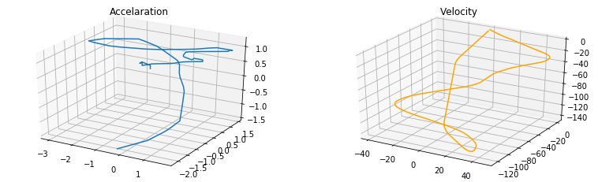

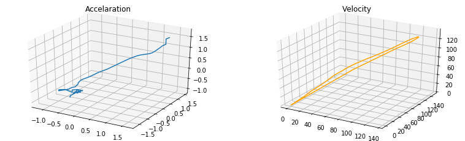

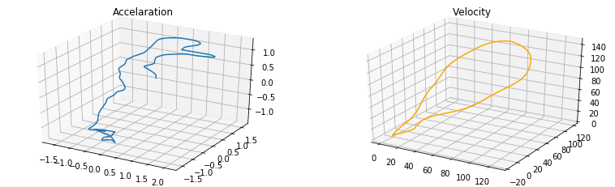

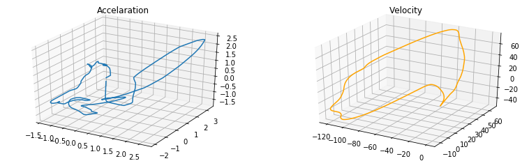

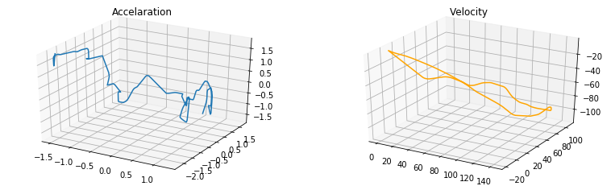

```python
def get_acc(df):
    return df.iloc[:,1:]

def plot_ts(df1,df2,df3,i):
    x=get_acc(df1)
    y=get_acc(df2)
    z=get_acc(df3)
    x_c=x.cumsum(axis=1)
    y_c=y.cumsum(axis=1)
    z_c=z.cumsum(axis=1)
    fig = plt.figure(figsize=plt.figaspect(0.3))
    fig.tight_layout()
    ax = fig.add_subplot(1, 2, 1, projection='3d')
    ax.plot(x.iloc[i,:], y.iloc[i,:], z.iloc[i,:])
    ax.set_title('Accelaration')

    ax = fig.add_subplot(1, 2, 2, projection='3d')
    ax.plot(x_c.iloc[i,:], y_c.iloc[i,:], z_c.iloc[i,:],c='orange')
    ax.set_title('Velocity')
    plt.show()

def plot_some_ts(num):
    for i in range(num):
        plot_ts(df1,df2,df3,i)

plot_some_ts(5)
```

## Task B

Tranform the data to long format.

```python
def long_format_ts(df1,df2,df3,velocity=False):
    list1=[]
    for idx in range(len(df1)):
        df=pd.concat([df1.iloc[idx,1:] , df2.iloc[idx,1:] ,df3.iloc[idx,1:]],axis=1)
        df.columns=['x','y','z']
        if velocity==True:
            df['x']=df['x'].cumsum(axis=0)
            df['y']=df['y'].cumsum(axis=0)
            df['z']=df['z'].cumsum(axis=0)
        df['label']=df1.iloc[idx,0]
        df['time series id']=idx
        df=df.reset_index().rename(columns={'index': 'time index'})
        df=df[['time series id','time index','label','x','y','z']]
        list1.append(df)
    return pd.concat(list1)

acc_long_df=long_format_ts(df1,df2,df3)
vel_long_df=long_format_ts(df1,df2,df3,True)
```

```python
acc_long_df
```

|  | time series id | time index | label | x | y | z |
| --- | --- | --- | --- | --- | --- | --- |
| 0 | 0 | 1 | 6.0 | -0.304243 | -2.119396 | -1.528965 |
| 1 | 0 | 2 | 6.0 | -0.304243 | -2.119396 | -1.528965 |
| 2 | 0 | 3 | 6.0 | -0.304243 | -2.119396 | -1.528965 |
| 3 | 0 | 4 | 6.0 | -0.304243 | -2.119396 | -1.528965 |
| 4 | 0 | 5 | 6.0 | -0.304243 | -2.119396 | -1.528965 |
| ... | ... | ... | ... | ... | ... | ... |
| 310 | 895 | 311 | 5.0 | 1.968575 | -0.886777 | -0.848602 |
| 311 | 895 | 312 | 5.0 | 2.028532 | -0.820651 | -0.828104 |
| 312 | 895 | 313 | 5.0 | 1.987267 | -0.754525 | -0.800426 |
| 313 | 895 | 314 | 5.0 | 1.887578 | -0.688399 | -0.768603 |
| 314 | 895 | 315 | 5.0 | 1.787888 | -0.622273 | -0.736781 |

282240 rows × 6 columns

```python
vel_long_df
```

|  | time series id | time index | label | x | y | z |
| --- | --- | --- | --- | --- | --- | --- |
| 0 | 0 | 1 | 6.0 | -3.042432e-01 | -2.119396e+00 | -1.528965e+00 |
| 1 | 0 | 2 | 6.0 | -6.084864e-01 | -4.238792e+00 | -3.057930e+00 |
| 2 | 0 | 3 | 6.0 | -9.127296e-01 | -6.358187e+00 | -4.586895e+00 |
| 3 | 0 | 4 | 6.0 | -1.216973e+00 | -8.477583e+00 | -6.115860e+00 |
| 4 | 0 | 5 | 6.0 | -1.521216e+00 | -1.059698e+01 | -7.644826e+00 |
| ... | ... | ... | ... | ... | ... | ... |
| 310 | 895 | 311 | 5.0 | -7.691264e+00 | 2.885849e+00 | 3.133914e+00 |
| 311 | 895 | 312 | 5.0 | -5.662732e+00 | 2.065198e+00 | 2.305810e+00 |
| 312 | 895 | 313 | 5.0 | -3.675465e+00 | 1.310673e+00 | 1.505384e+00 |
| 313 | 895 | 314 | 5.0 | -1.787888e+00 | 6.222737e-01 | 7.367803e-01 |
| 314 | 895 | 315 | 5.0 | 6.081000e-07 | 1.919999e-07 | -2.740001e-07 |

282240 rows × 6 columns

Apply PCA transformation

```python
from sklearn.decomposition import PCA

def pca_transform(df):
    pca = PCA(n_components=1)
    df['PCA_1D']=pca.fit_transform((df[['x','y','z']]))
    return df

pca_acc=pca_transform(acc_long_df)
pca_vel=pca_transform(vel_long_df)

def get_single_ts(df,i):
    return df.loc[df['time series id']==i]

def get_same_label_ts(df,i):
    return df.loc[df['label']==i]

pca_acc
```

|  | time series id | time index | label | x | y | z | PCA_1D |
| --- | --- | --- | --- | --- | --- | --- | --- |
| 0 | 0 | 1 | 6.0 | -0.304243 | -2.119396 | -1.528965 | -2.492575 |
| 1 | 0 | 2 | 6.0 | -0.304243 | -2.119396 | -1.528965 | -2.492575 |
| 2 | 0 | 3 | 6.0 | -0.304243 | -2.119396 | -1.528965 | -2.492575 |
| 3 | 0 | 4 | 6.0 | -0.304243 | -2.119396 | -1.528965 | -2.492575 |
| 4 | 0 | 5 | 6.0 | -0.304243 | -2.119396 | -1.528965 | -2.492575 |
| ... | ... | ... | ... | ... | ... | ... | ... |
| 310 | 895 | 311 | 5.0 | 1.968575 | -0.886777 | -0.848602 | -0.262244 |
| 311 | 895 | 312 | 5.0 | 2.028532 | -0.820651 | -0.828104 | -0.177775 |
| 312 | 895 | 313 | 5.0 | 1.987267 | -0.754525 | -0.800426 | -0.132596 |
| 313 | 895 | 314 | 5.0 | 1.887578 | -0.688399 | -0.768603 | -0.110094 |
| 314 | 895 | 315 | 5.0 | 1.787888 | -0.622273 | -0.736781 | -0.087592 |

282240 rows × 7 columns

```python
pca_vel
```

|  | time series id | time index | label | x | y | z | PCA_1D |
| --- | --- | --- | --- | --- | --- | --- | --- |
| 0 | 0 | 1 | 6.0 | -3.042432e-01 | -2.119396e+00 | -1.528965e+00 | -1.189582 |
| 1 | 0 | 2 | 6.0 | -6.084864e-01 | -4.238792e+00 | -3.057930e+00 | -3.806824 |
| 2 | 0 | 3 | 6.0 | -9.127296e-01 | -6.358187e+00 | -4.586895e+00 | -6.424067 |
| 3 | 0 | 4 | 6.0 | -1.216973e+00 | -8.477583e+00 | -6.115860e+00 | -9.041309 |
| 4 | 0 | 5 | 6.0 | -1.521216e+00 | -1.059698e+01 | -7.644826e+00 | -11.658552 |
| ... | ... | ... | ... | ... | ... | ... | ... |
| 310 | 895 | 311 | 5.0 | -7.691264e+00 | 2.885849e+00 | 3.133914e+00 | 3.853538 |
| 311 | 895 | 312 | 5.0 | -5.662732e+00 | 2.065198e+00 | 2.305810e+00 | 3.166107 |
| 312 | 895 | 313 | 5.0 | -3.675465e+00 | 1.310673e+00 | 1.505384e+00 | 2.537750 |
| 313 | 895 | 314 | 5.0 | -1.787888e+00 | 6.222737e-01 | 7.367803e-01 | 1.958268 |
| 314 | 895 | 315 | 5.0 | 6.081000e-07 | 1.919999e-07 | -2.740001e-07 | 1.427661 |

282240 rows × 7 columns

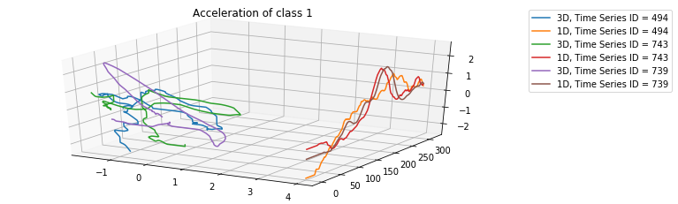

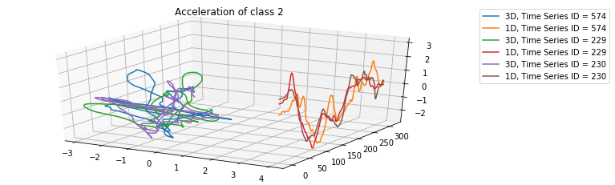

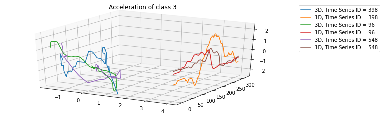

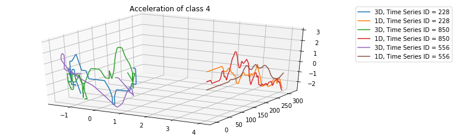

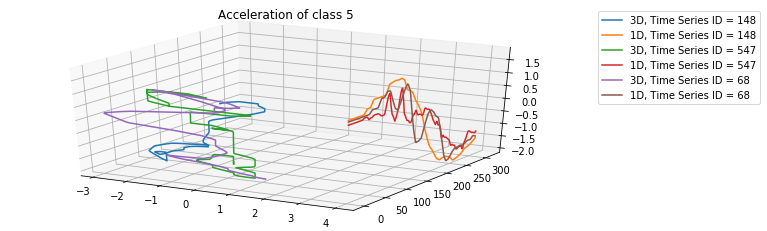

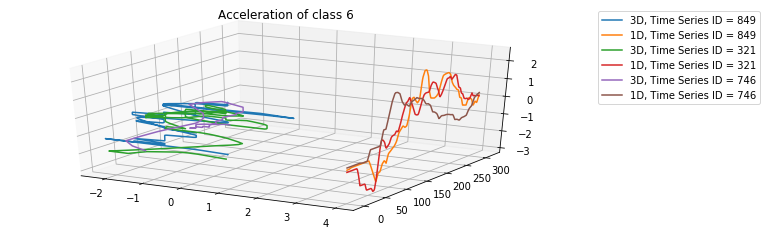

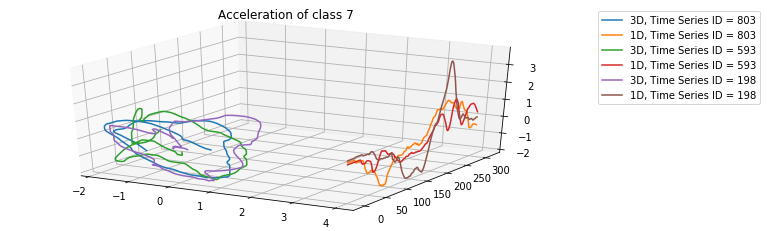

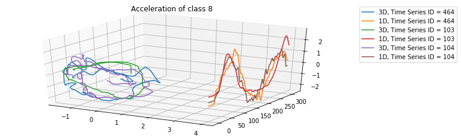

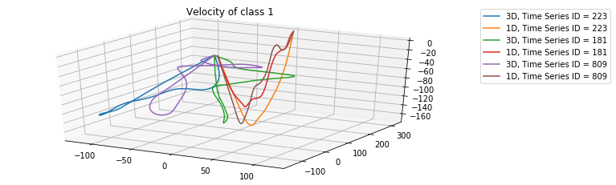

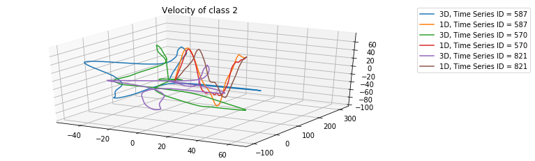

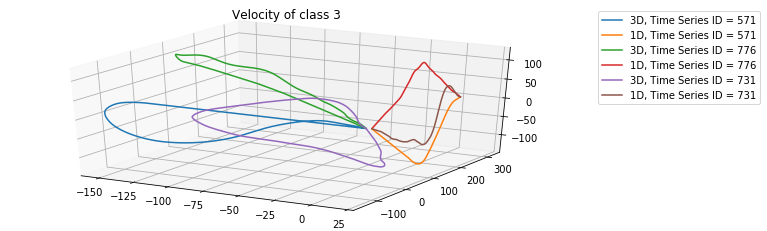

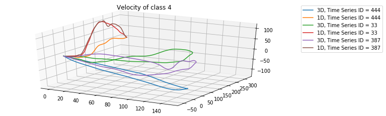

[4 more figures not shown]

```python
def compare_plots(df,title):
    for i in range(1,9):
        a=get_same_label_ts(df,i) #get time series data with same label
        j1=random.choice(list(set(list(a['time series id'])))) #randomly select a time series id
        s=get_single_ts(a,j1)

        fig = plt.figure(figsize=plt.figaspect(0.4))
        ax = fig.add_subplot(1, 1, 1, projection='3d')
        ax.set_title(title + ' of class ' + str(i))

        ax.plot(s['x'], s['y'], s['z'],label='3D, Time Series ID = ' + str(j1))
        ax.plot(np.zeros(len(s))+4,np.arange(len(s)),s['PCA_1D'],label='1D, Time Series ID = ' + str(j1))

        j2=random.choice(list(set(list(a['time series id']))))
        s=get_single_ts(a,j2)

        ax.plot(s['x'], s['y'], s['z'],label='3D, Time Series ID = ' + str(j2))
        ax.plot(np.zeros(len(s))+4,np.arange(len(s)),s['PCA_1D'],label='1D, Time Series ID = ' + str(j2))


        j3=random.choice(list(set(list(a['time series id']))))
        s=get_single_ts(a,j3)

        ax.plot(s['x'], s['y'], s['z'],label='3D, Time Series ID = ' + str(j3))
        ax.plot(np.zeros(len(s))+4,np.arange(len(s)),s['PCA_1D'],label='1D, Time Series ID = ' + str(j3))
        ax.legend(bbox_to_anchor=(1.05, 1), loc=2)

        plt.show()


compare_plots(pca_acc,'Acceleration')
compare_plots(pca_vel,'Velocity')
```

Comparasion between plots. I plotted in 3D format. This makes it possible to observe the real data and transformed data (PCA) at the same time. The PCA data is plotted by denoting a constant for the dimension x. This way it acts like 2D in a 3D setting.

As seen from the graphs, when we decrease the dimension by PCA, we can plot two dimensional plots. However, plots don't show any similarities compare to their 3d versions in terms of shape. When we look at two dimensional plots, we can see that they follow some characteristics. In other words, time series in the same class mostly have similar two dimensional graphs. For instance, Accelearation of class 1 2 and 8, plots look very similar to each other. When we look at different classes, we see peeks and valleys at different times compare to other classes. However is not very easy to distinguish classes by just looking at two dimensional graphs.

## Task C

Apply PCA to all classes.

```python
def get_pca_info(df,n): #returns PCA summary for n th component.
    pca = PCA(n_components=n)
    pca.fit(df[['x','y','z']])
    pca_info = pd.DataFrame(pca.components_)
    pca_info['explained_variance'] = pca.explained_variance_
    pca_info['explained_variance_ratio'] = pca.explained_variance_ratio_
    pca_info['cumulative_explained_variance_ratio'] = pca.explained_variance_ratio_.cumsum()
    return pca_info.iloc[[n-1]]


def pca_info_wrt_labels(df,n): #return PCA summary for all classes
    dic = {i:get_pca_info(get_same_label_ts(df,i),n) for i in range(1,9)}
    dic['benchmark']=get_pca_info(df,n)

    df1=pd.DataFrame(pd.concat(dic.values()))
    df1['label']=dic.keys()
    df1.set_index('label',inplace=True)
    df1.columns=[str(n)+'_component_x',str(n)+'_component_y',str(n)+'_component_z','explained_variance','explained_variance_ratio','cumulative_explained_variance_ratio']
    return df1

acc_pca_info_wrt_labels_c1=pca_info_wrt_labels(acc_long_df,1)

acc_pca_info_wrt_labels_c1
```

| label | 1_component_x | 1_component_y | 1_component_z | explained_variance | explained_variance_ratio | cumulative_explained_variance_ratio |
| --- | --- | --- | --- | --- | --- | --- |
| 1 | 0.356794 | 0.691143 | 0.628506 | 1.383230 | 0.462533 | 0.462533 |
| 2 | 0.455418 | 0.684555 | 0.569192 | 1.532807 | 0.512548 | 0.512548 |
| 3 | 0.674723 | 0.530688 | -0.512951 | 1.617131 | 0.540744 | 0.540744 |
| 4 | 0.680632 | 0.634207 | -0.366772 | 1.645194 | 0.550129 | 0.550129 |
| 5 | 0.398877 | 0.642590 | 0.654198 | 1.935555 | 0.647223 | 0.647223 |
| 6 | -0.206027 | 0.679723 | 0.703939 | 1.710075 | 0.571824 | 0.571824 |
| 7 | 0.229030 | 0.715026 | 0.660517 | 1.552709 | 0.519203 | 0.519203 |
| 8 | 0.574434 | 0.692792 | 0.435963 | 1.834497 | 0.613427 | 0.613427 |
| benchmark | 0.426846 | 0.721265 | 0.545509 | 1.467118 | 0.490595 | 0.490595 |

```python
acc_pca_info_wrt_labels_c2=pca_info_wrt_labels(acc_long_df,2)

acc_pca_info_wrt_labels_c2
```

| label | 2_component_x | 2_component_y | 2_component_z | explained_variance | explained_variance_ratio | cumulative_explained_variance_ratio |
| --- | --- | --- | --- | --- | --- | --- |
| 1 | -0.896295 | 0.063601 | 0.438875 | 0.966347 | 0.323133 | 0.785666 |
| 2 | -0.801469 | 0.036891 | 0.596897 | 0.934599 | 0.312516 | 0.825064 |
| 3 | 0.009099 | 0.688955 | 0.724747 | 0.895013 | 0.299279 | 0.840023 |
| 4 | 0.112584 | 0.404137 | 0.907743 | 0.919766 | 0.307556 | 0.857685 |
| 5 | -0.915447 | 0.320595 | 0.243259 | 0.821235 | 0.274610 | 0.921833 |
| 6 | 0.964243 | 0.263569 | 0.027710 | 0.985263 | 0.329458 | 0.901282 |
| 7 | -0.924814 | -0.051905 | 0.376861 | 1.025855 | 0.343031 | 0.862234 |
| 8 | 0.583911 | 0.026438 | -0.811387 | 0.933258 | 0.312067 | 0.925494 |
| benchmark | 0.776311 | 0.017149 | -0.630116 | 1.036813 | 0.346704 | 0.837299 |

By including 2 component, now we better explained the variance in the data.

```python
acc_pca_info_wrt_labels_c3=pca_info_wrt_labels(acc_long_df,3)

acc_pca_info_wrt_labels_c3
```

| label | 3_component_x | 3_component_y | 3_component_z | explained_variance | explained_variance_ratio | cumulative_explained_variance_ratio |
| --- | --- | --- | --- | --- | --- | --- |
| 1 | -0.263351 | 0.719914 | -0.642160 | 0.640977 | 0.214334 | 1.0 |
| 2 | -0.387611 | 0.728027 | -0.565450 | 0.523158 | 0.174936 | 1.0 |
| 3 | 0.738015 | -0.493671 | 0.460026 | 0.478422 | 0.159977 | 1.0 |
| 4 | -0.723923 | 0.659132 | -0.203667 | 0.425602 | 0.142315 | 1.0 |
| 5 | 0.053417 | 0.695914 | -0.716135 | 0.233761 | 0.078167 | 1.0 |
| 6 | 0.166701 | -0.684477 | 0.709720 | 0.295224 | 0.098718 | 1.0 |
| 7 | 0.303750 | -0.697169 | 0.649378 | 0.411997 | 0.137766 | 1.0 |
| 8 | -0.573649 | 0.720652 | -0.389342 | 0.222817 | 0.074506 | 1.0 |
| benchmark | -0.463836 | 0.692447 | -0.552606 | 0.486556 | 0.162701 | 1.0 |

```python
vel_pca_info_wrt_labels_c1=pca_info_wrt_labels(vel_long_df,1)

vel_pca_info_wrt_labels_c1
```

| label | 1_component_x | 1_component_y | 1_component_z | explained_variance | explained_variance_ratio | cumulative_explained_variance_ratio |
| --- | --- | --- | --- | --- | --- | --- |
| 1 | 0.505521 | 0.640113 | 0.578537 | 2904.346597 | 0.514514 | 0.514514 |
| 2 | 0.099627 | 0.864973 | 0.491829 | 2270.466057 | 0.709516 | 0.709516 |
| 3 | -0.550057 | -0.726543 | 0.411793 | 4254.514752 | 0.489100 | 0.489100 |
| 4 | 0.583795 | 0.665633 | -0.464883 | 4241.420647 | 0.465397 | 0.465397 |
| 5 | 0.760539 | 0.448262 | 0.469725 | 4965.224738 | 0.545800 | 0.545800 |
| 6 | -0.165512 | 0.793423 | 0.585736 | 7165.451642 | 0.624807 | 0.624807 |
| 7 | -0.338955 | -0.806445 | -0.484516 | 3273.709117 | 0.565475 | 0.565475 |
| 8 | 0.585936 | 0.683155 | 0.435865 | 2758.048548 | 0.550660 | 0.550660 |
| benchmark | 0.215773 | 0.784872 | 0.580878 | 6605.421232 | 0.555786 | 0.555786 |

```python
vel_pca_info_wrt_labels_c2=pca_info_wrt_labels(vel_long_df,2)

vel_pca_info_wrt_labels_c2
```

| label | 2_component_x | 2_component_y | 2_component_z | explained_variance | explained_variance_ratio | cumulative_explained_variance_ratio |
| --- | --- | --- | --- | --- | --- | --- |
| 1 | -0.785633 | 0.618689 | 0.001941 | 1776.172020 | 0.314654 | 0.829168 |
| 2 | -0.993701 | 0.061005 | 0.094000 | 634.035767 | 0.198135 | 0.907651 |
| 3 | -0.222027 | 0.602568 | 0.766561 | 3041.890060 | 0.349696 | 0.838796 |
| 4 | 0.169032 | 0.460394 | 0.871473 | 3449.501811 | 0.378503 | 0.843900 |
| 5 | -0.647942 | 0.570601 | 0.504565 | 3562.638586 | 0.391621 | 0.937421 |
| 6 | -0.981351 | -0.191375 | -0.018070 | 3231.594299 | 0.281786 | 0.906592 |
| 7 | -0.858742 | 0.054848 | 0.509464 | 1637.247744 | 0.282805 | 0.848280 |
| 8 | 0.555583 | 0.052895 | -0.829777 | 1405.578137 | 0.280632 | 0.831291 |
| benchmark | -0.886446 | -0.092005 | 0.453595 | 3832.670633 | 0.322484 | 0.878270 |

```python
vel_pca_info_wrt_labels_c3=pca_info_wrt_labels(vel_long_df,3)

vel_pca_info_wrt_labels_c3
```

| label | 3_component_x | 3_component_y | 3_component_z | explained_variance | explained_variance_ratio | cumulative_explained_variance_ratio |
| --- | --- | --- | --- | --- | --- | --- |
| 1 | -0.356692 | -0.455499 | 0.815654 | 964.317290 | 0.170832 | 1.0 |
| 2 | 0.051303 | -0.498096 | 0.865603 | 295.518904 | 0.092349 | 1.0 |
| 3 | -0.805072 | 0.330223 | -0.492759 | 1402.258277 | 0.161204 | 1.0 |
| 4 | -0.794110 | 0.587342 | -0.156263 | 1422.627655 | 0.156100 | 1.0 |
| 5 | -0.041848 | -0.688096 | 0.724412 | 569.287153 | 0.062579 | 1.0 |
| 6 | -0.097758 | 0.577803 | -0.810301 | 1071.223941 | 0.093408 | 1.0 |
| 7 | -0.384280 | 0.588760 | -0.711119 | 878.353210 | 0.151720 | 1.0 |
| 8 | 0.589922 | -0.728355 | 0.348556 | 844.998063 | 0.168709 | 1.0 |
| benchmark | -0.409457 | 0.612790 | -0.675894 | 1446.746061 | 0.121730 | 1.0 |

## Task D

Obtain symmetric distance matrix.

```python
from sklearn.metrics import pairwise_distances

def get_labels(df):
    return df.iloc[:,0]

def get_pairwise_distance(df1,df2,df3,cumsum=False,n=1):
    if cumsum==True:
        df1=df1.iloc[:,n:].cumsum()
        df2=df2.iloc[:,n:].cumsum()
        df3=df3.iloc[:,n:].cumsum()
        n=0
    x_dist=pairwise_distances(df1.iloc[:,n:])
    y_dist=pairwise_distances(df2.iloc[:,n:])
    z_dist=pairwise_distances(df3.iloc[:,n:])
    return x_dist+y_dist+z_dist

acc_total_dist = get_pairwise_distance(df1,df2,df3)
vel_total_dist = get_pairwise_distance(df1,df2,df3,cumsum=True)
```

```python
pd.DataFrame(acc_total_dist)
```

|  | 0 | 1 | 2 | 3 | 4 | 5 | 6 | 7 | 8 | 9 | ... | 886 | 887 | 888 | 889 | 890 | 891 | 892 | 893 | 894 | 895 |
| --- | --- | --- | --- | --- | --- | --- | --- | --- | --- | --- | --- | --- | --- | --- | --- | --- | --- | --- | --- | --- | --- |
| 0 | 0.000002 | 8.768508e+01 | 7.949081e+01 | 86.407000 | 7.003667e+01 | 82.726427 | 84.605986 | 57.853864 | 65.084971 | 48.365078 | ... | 79.660044 | 68.612071 | 71.047374 | 62.164942 | 90.623621 | 58.456040 | 68.997596 | 7.381065e+01 | 81.064041 | 90.190673 |
| 1 | 87.685079 | 4.768372e-07 | 4.496116e+01 | 63.116745 | 5.475039e+01 | 63.150540 | 65.146619 | 86.151956 | 60.939958 | 99.707550 | ... | 79.078956 | 84.347136 | 55.626115 | 83.347607 | 47.370852 | 76.897658 | 94.646271 | 7.073689e+01 | 73.146395 | 37.503138 |
| 2 | 79.490815 | 4.496116e+01 | 3.371748e-07 | 74.071904 | 5.152769e+01 | 60.076187 | 91.552591 | 76.051910 | 60.333320 | 93.180185 | ... | 86.075215 | 72.683598 | 54.984918 | 82.526313 | 55.797566 | 61.405177 | 86.213275 | 8.212989e+01 | 91.198174 | 38.758188 |
| 3 | 86.407000 | 6.311674e+01 | 7.407190e+01 | 0.000001 | 7.631456e+01 | 66.352272 | 67.562412 | 96.094497 | 85.504458 | 75.283066 | ... | 70.556800 | 63.756430 | 79.889715 | 76.075716 | 57.683123 | 75.028488 | 77.329809 | 6.317239e+01 | 63.864824 | 64.885296 |
| 4 | 70.036673 | 5.475039e+01 | 5.152769e+01 | 76.314556 | 9.536743e-07 | 63.144161 | 77.183649 | 58.137359 | 32.399846 | 82.327986 | ... | 81.699278 | 93.182722 | 26.864291 | 61.493925 | 83.147321 | 74.660572 | 76.686200 | 7.782652e+01 | 75.661318 | 67.133220 |
| ... | ... | ... | ... | ... | ... | ... | ... | ... | ... | ... | ... | ... | ... | ... | ... | ... | ... | ... | ... | ... | ... |
| 891 | 58.456040 | 7.689766e+01 | 6.140518e+01 | 75.028488 | 7.466057e+01 | 78.674408 | 78.287506 | 71.561914 | 78.521140 | 66.187412 | ... | 78.449718 | 58.967235 | 74.677890 | 80.990983 | 63.707155 | 0.000000 | 78.006455 | 7.715673e+01 | 75.970756 | 74.769483 |
| 892 | 68.997596 | 9.464627e+01 | 8.621327e+01 | 77.329809 | 7.668620e+01 | 65.623223 | 79.263482 | 61.197581 | 70.601638 | 62.060551 | ... | 76.179821 | 64.853839 | 76.926560 | 59.673590 | 86.604018 | 78.006455 | 0.000001 | 7.222640e+01 | 65.819435 | 84.933726 |
| 893 | 73.810654 | 7.073689e+01 | 8.212989e+01 | 63.172388 | 7.782652e+01 | 74.228577 | 61.705859 | 85.697459 | 80.743545 | 77.244815 | ... | 80.337187 | 72.661868 | 78.554756 | 67.376223 | 76.626898 | 77.156729 | 72.226402 | 3.371748e-07 | 61.258217 | 77.241923 |
| 894 | 81.064041 | 7.314640e+01 | 9.119817e+01 | 63.864824 | 7.566132e+01 | 81.694608 | 33.162698 | 74.406739 | 75.765164 | 74.074199 | ... | 59.201977 | 71.933800 | 71.648775 | 66.631584 | 77.218317 | 75.970756 | 65.819435 | 6.125822e+01 | 0.000002 | 83.517519 |
| 895 | 90.190673 | 3.750314e+01 | 3.875819e+01 | 64.885296 | 6.713322e+01 | 55.814791 | 79.634802 | 86.563172 | 69.568759 | 95.994688 | ... | 83.543467 | 78.794769 | 67.865592 | 86.519196 | 42.197870 | 74.769483 | 84.933726 | 7.724192e+01 | 83.517519 | 0.000000 |

896 rows × 896 columns

Apply MDS.

```python
from sklearn.manifold import MDS

def apply_mds(data):
    model = MDS(n_components = 2,dissimilarity='precomputed',n_jobs=-1)
    return model.fit_transform(data)

acc_mds=apply_mds(acc_total_dist)
```

```python
pd.DataFrame(acc_mds)
```

|  | 0 | 1 |
| --- | --- | --- |
| 0 | -42.323247 | 39.090865 |
| 1 | -0.058206 | -56.316714 |
| 2 | -33.905098 | -47.346717 |
| 3 | 46.057818 | -32.885418 |
| 4 | -34.464604 | -20.885728 |
| ... | ... | ... |
| 891 | -38.326257 | 5.481502 |
| 892 | -7.095948 | 33.827197 |
| 893 | 55.981312 | -17.068595 |
| 894 | 43.193014 | 4.050103 |
| 895 | -8.908487 | -59.074505 |

896 rows × 2 columns

Visualize MDS.

```python
def visualize_data(data,labels):
    sc=plt.scatter(data[:, 0], data[:, 1],
            c=labels, edgecolor='black', alpha=0.6,
            cmap=plt.cm.get_cmap('Spectral', 8))
    plt.colorbar(sc)
```

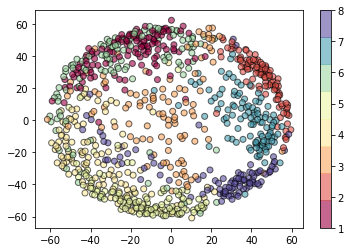

```python
visualize_data(acc_mds,get_labels(df1))
```